# Imputation

Nancy Briggs

2024-10-08

Imputation for:

1. Sensitivity (NICHD-Sensitivity)
2. Positive parenting verbalizations (DPICS – LP)
3. Negative parenting verbalizations (DPICS – NTA)
4. Parental reflectiveness (CCQE)
5. BITSEA-competence
6. CBCL-externalizing
7. BITSEA-problem

## Imputation details

- Parenting sensitivity
- Positive parenting verbalizations
- Negative parenting verbalizations
- Parental reflectiveness
- BITSEA-competence
- BITSEA-problem
- CBCL-externalizing

Predictors in the imputation model were randomisation group, child age and sex, mother age, education and ethnicity, father age, education and ethnicity, number of people in the household, family income and marital status of the parents.

Twenty-five datasets were imputed, using the normal method for continuous, normal outcomes, and predictive mean matching for positive and negative verbalisations and predictor variables. No values for the Follow up time point were imputed for the Waitlist group.

The unadjusted mixed model was run on each imputed dataset, and all results and effect size were aggregated using Rubin’s Rules (1987).

```r
library(lme4)
library(mice)
library(tidyverse)
library(tidyselect)
library(emmeans)
library(kableExtra)
library(ggplot2)
library(lmerTest)
library(effectsize)
library(boot)
library(VIM)
library(emmeans)
library(broom.mixed)
library(huxtable)
```

```r
mi<-data %>%
  relocate(group, .after="id") %>%
  relocate(parent_total_verbalisations_time_2, .after="parent_total_verbalisations_time_1") %>%
  relocate(parent_total_verbalisations_time_3, .after="parent_total_verbalisations_time_2") %>%
  relocate(parent_total_nta_time_2, .after="parent_total_nta_time_1") %>%
  relocate(parent_total_nta_time_3, .after="parent_total_nta_time_2") %>%
  relocate(parent_total_lp_time_2, .after="parent_total_lp_time_1") %>%
  relocate(parent_total_lp_time_3, .after="parent_total_lp_time_2")
```

# Multiple Imputation

## Checking correlations

Look at correlations among the variables.

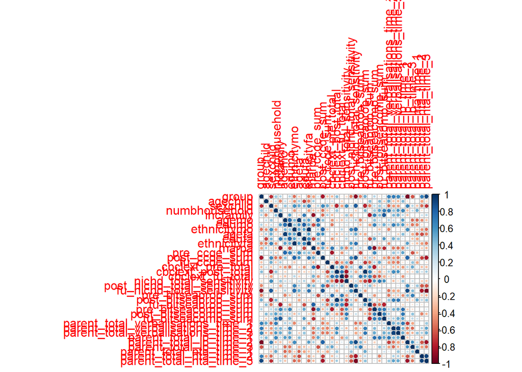

```r
# check correlations
mcl_dat = mi %>%
  dplyr::select(-id)
Xmat <- model.matrix(~., data = mcl_dat )
corrplot::corrplot(cor(Xmat[,-1]))
```

## Checking missing data patterns

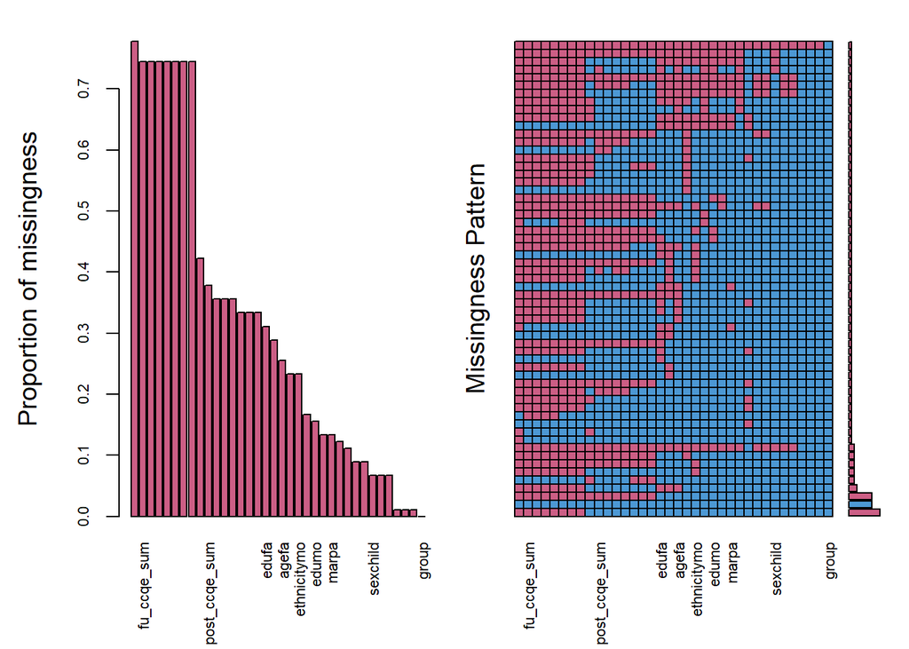

```
##
##  Variables sorted by number of missings:
##                            Variable      Count
##          fu_nichd_total_sensitivity 0.77777778
##                         fu_ccqe_sum 0.74444444
##                    cbclext_fu_total 0.74444444
##                   fu_bitseaprob_sum 0.74444444
##                   fu_bitseacomp_sum 0.74444444
##  parent_total_verbalisations_time_3 0.74444444
##              parent_total_lp_time_3 0.74444444
##             parent_total_nta_time_3 0.74444444
##        post_nichd_total_sensitivity 0.42222222
##                       post_ccqe_sum 0.37777778
##                  cbclext_post_total 0.35555556
##                 post_bitseaprob_sum 0.35555556
##                 post_bitseacomp_sum 0.35555556
##  parent_total_verbalisations_time_2 0.33333333
##              parent_total_lp_time_2 0.33333333
##             parent_total_nta_time_2 0.33333333
##                               edufa 0.31111111
##                         ethnicityfa 0.28888889
##                               agefa 0.25555556
##                       numbhousehold 0.23333333
##                         ethnicitymo 0.23333333
##                               agemo 0.16666667
##                               edumo 0.15555556
##                           incfamily 0.13333333
##                               marpa 0.13333333
##                            agechild 0.12222222
##             nichd_total_sensitivity 0.11111111
##                  pre_bitseaprob_sum 0.08888889
##                  pre_bitseacomp_sum 0.08888889
##                            sexchild 0.06666667
##                        pre_ccqe_sum 0.06666667
##                   cbclext_pre_total 0.06666667
##  parent_total_verbalisations_time_1 0.01111111
##              parent_total_lp_time_1 0.01111111
##             parent_total_nta_time_1 0.01111111
##                               group 0.00000000
```

```
##
##  Missings in variables:
##                            Variable Count
##                            agechild    11
##                            sexchild     6
##                       numbhousehold    21
##                           incfamily    12
##                               agemo    15
##                               edumo    14
##                         ethnicitymo    21
##                               agefa    23
##                               edufa    28
##                         ethnicityfa    26
##                               marpa    12
##                        pre_ccqe_sum     6
##                       post_ccqe_sum    34
##                         fu_ccqe_sum    67
##                   cbclext_pre_total     6
##                  cbclext_post_total    32
##                    cbclext_fu_total    67
##             nichd_total_sensitivity    10
##        post_nichd_total_sensitivity    38
##          fu_nichd_total_sensitivity    70
##                  pre_bitseaprob_sum     8
##                 post_bitseaprob_sum    32
##                   fu_bitseaprob_sum    67
##                  pre_bitseacomp_sum     8
##                 post_bitseacomp_sum    32
##                   fu_bitseacomp_sum    67
##  parent_total_verbalisations_time_1     1
##              parent_total_lp_time_1     1
##             parent_total_nta_time_1     1
##  parent_total_verbalisations_time_2    30
##              parent_total_lp_time_2    30
##             parent_total_nta_time_2    30
##  parent_total_verbalisations_time_3    67
##              parent_total_lp_time_3    67
##             parent_total_nta_time_3    67
```

```r
# Create custom imputation for waitlist==3 & time 3 measures
# make a logical vector to say where you do and
# don't want imputing to occur
here <- mi_forimp %>%
  mutate(across(c(fu_ccqe_sum,cbclext_fu_total,fu_nichd_total_sensitivity,fu_bitseaprob_sum,fu_bitseacomp_sum,
                  parent_total_verbalisations_time_3,parent_total_lp_time_3,parent_total_nta_time_3),
                ~ case_when(group==3  ~ FALSE,
                            group!=3  ~ TRUE))) %>%
  mutate(across(c(pre_ccqe_sum,cbclext_pre_total,nichd_total_sensitivity,pre_bitseaprob_sum,pre_bitseacomp_sum,
                  parent_total_verbalisations_time_1,parent_total_lp_time_1,parent_total_nta_time_1),
                ~ case_when(group<=3  ~ TRUE))) %>%
  mutate(across(c(post_ccqe_sum,cbclext_post_total,post_nichd_total_sensitivity,post_bitseaprob_sum,post_bitseacomp_sum,
                  parent_total_verbalisations_time_2,parent_total_lp_time_2,parent_total_nta_time_2) ,
                ~ case_when(group<=3  ~ TRUE))) %>%
  mutate(across(c(agechild,sexchild, numbhousehold,incfamily, agemo, agefa, edumo, edufa, ethnicitymo, ethnicityfa, marpa) ,
                ~ case_when(group<=3  ~ TRUE))) %>%
  mutate(group = FALSE)


meth <- ini$meth
# normal for most outcomes
meth[c(14:28)] <- "norm"
# PMM for NTA and LP
meth[c(29:37)] <- "pmm"
# pmm
meth[c(3:13)] <- "pmm"

# impute
imp <- mice(mi_forimp, m = 25,  where = here, meth=meth, pred = pred, visit = "monotone",
            print = TRUE, maxit = 20)
summary(imp)

save(imp, file ="imputed_full_allvars_long_pan") #
```

### Evaluation of imputations

```r
 # load previously imputed data
load(file ="imputed_full_allvars_long_pan")

# check for problems
imp$loggedEvents
```

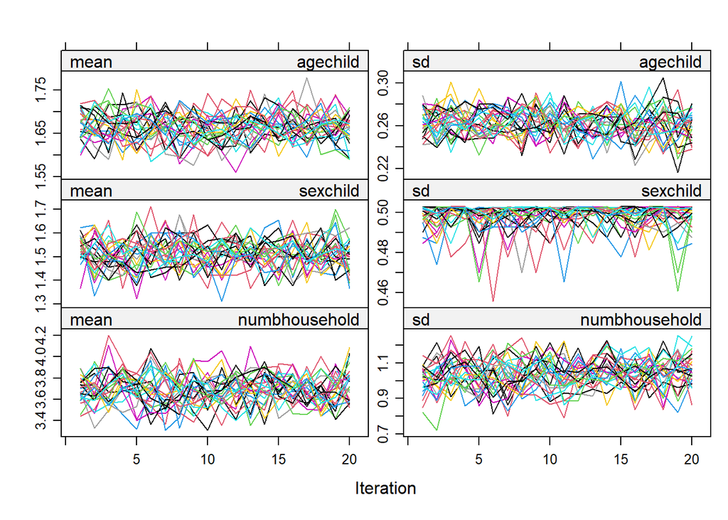

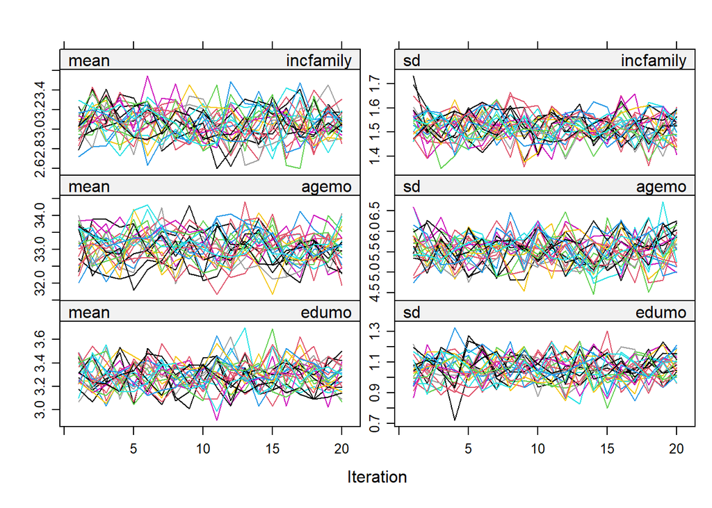

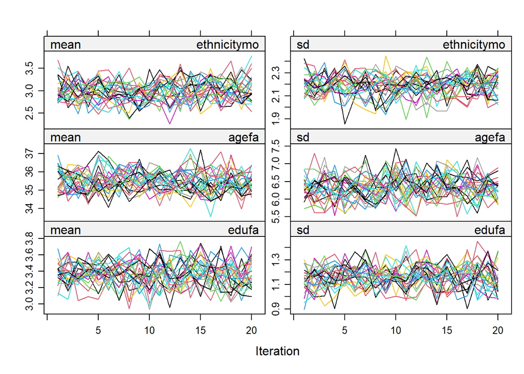

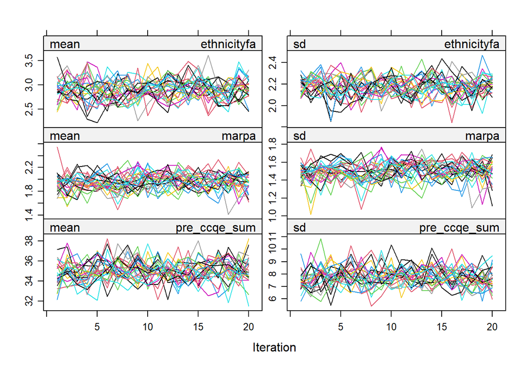

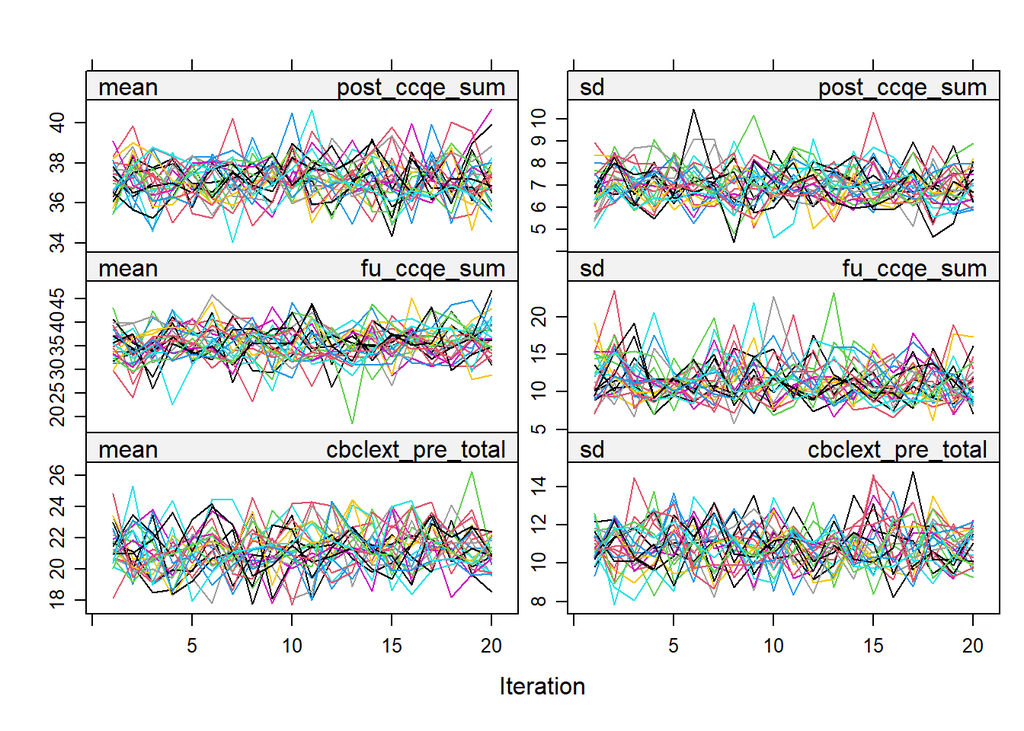

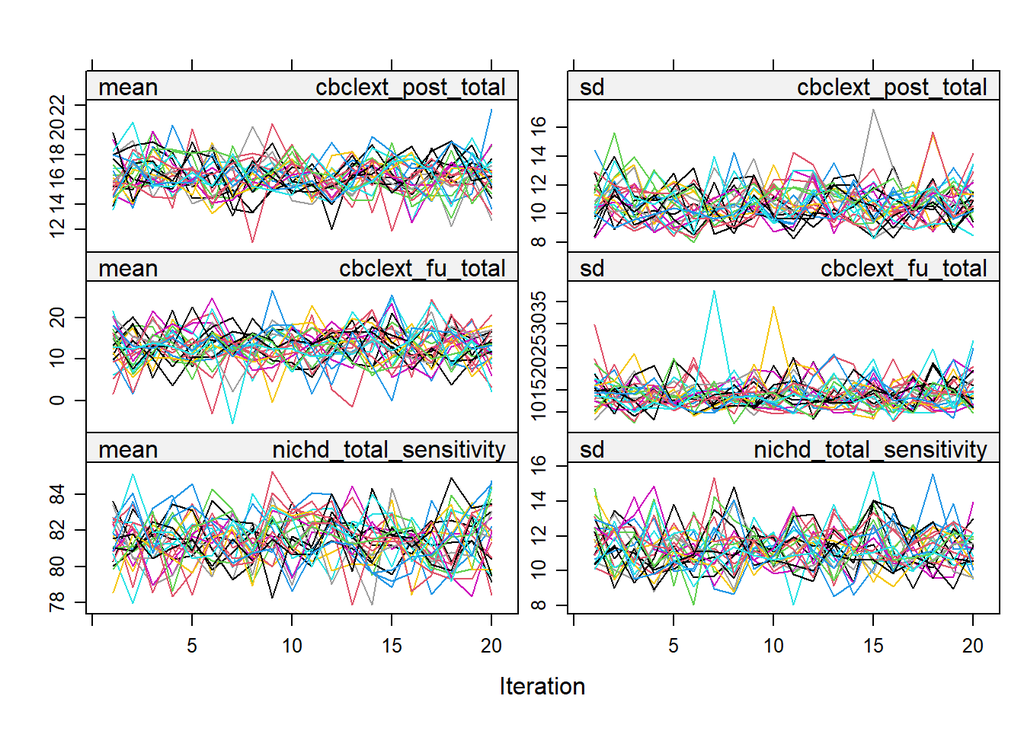

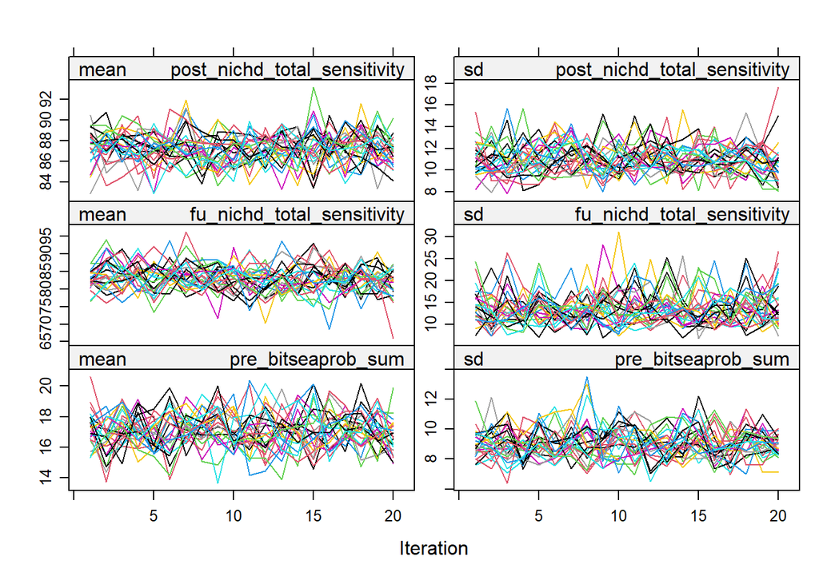

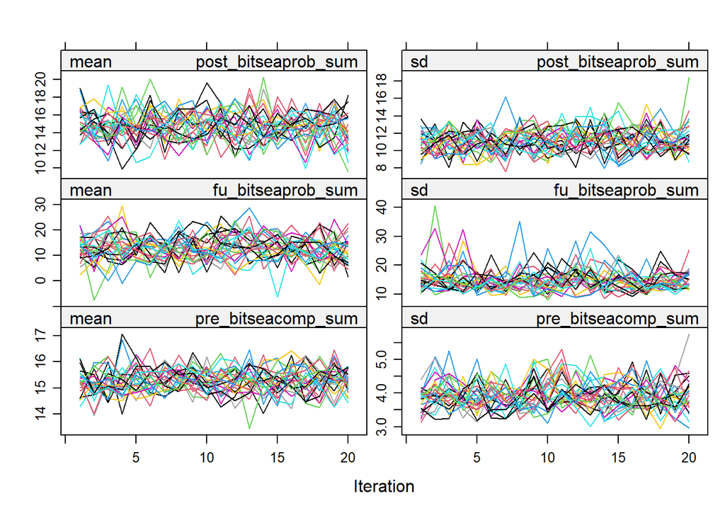

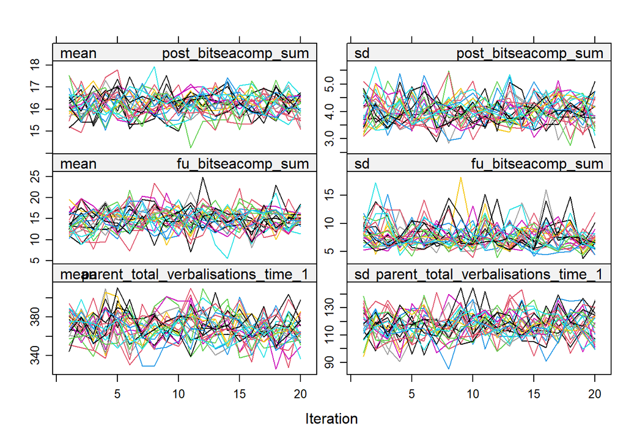

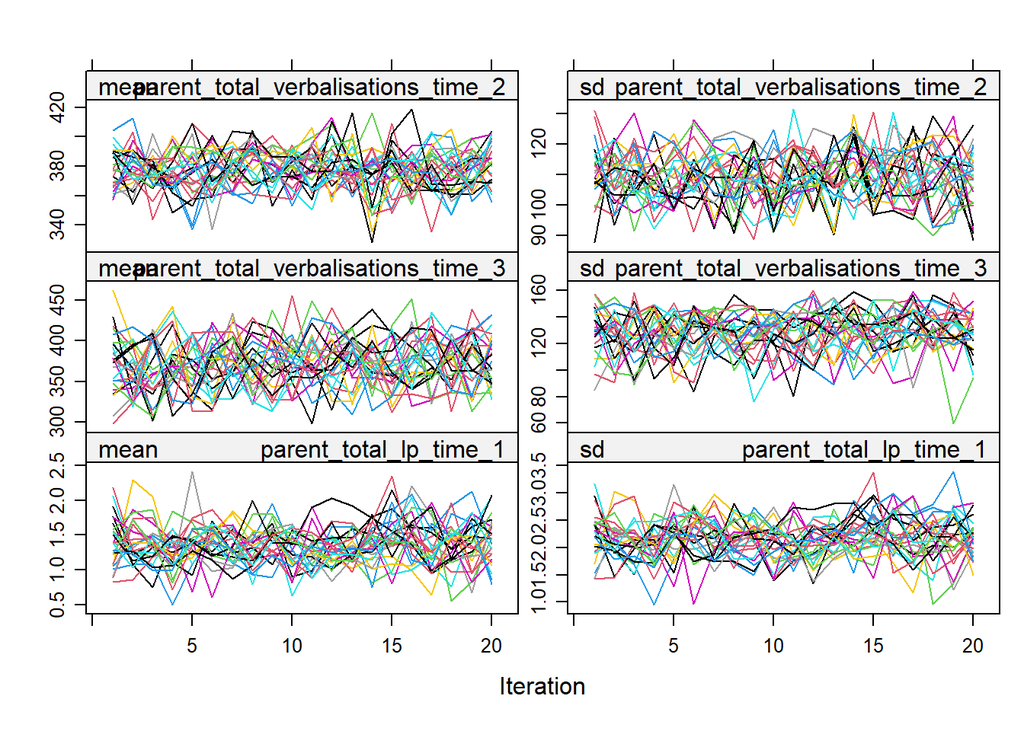

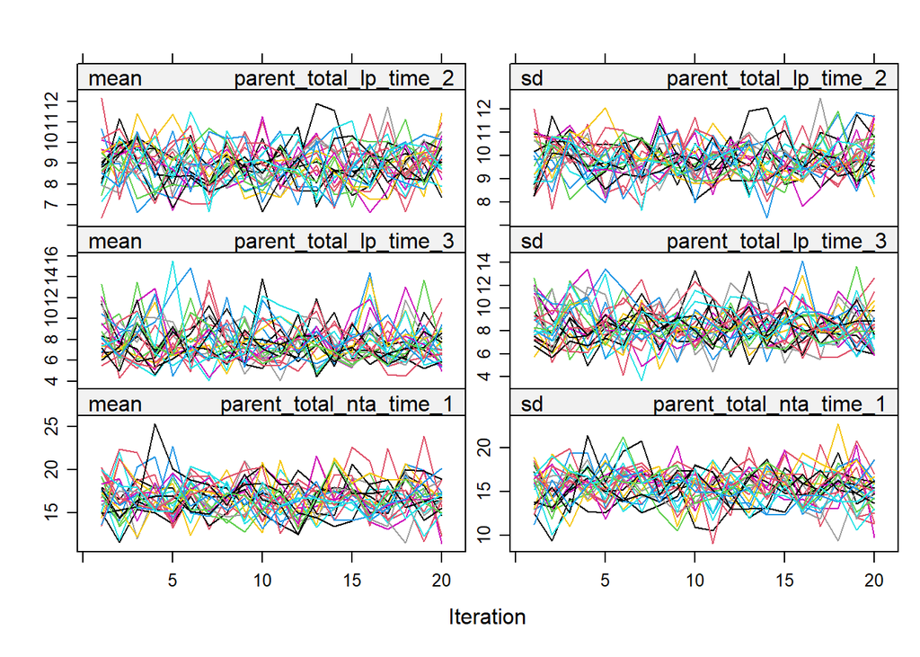

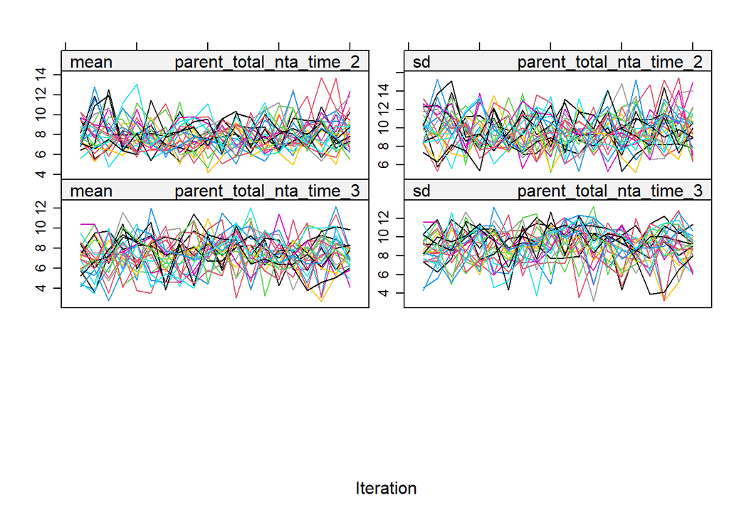

```r
# plot convergence diagnostic
plot(imp)
```

There were no problems with the imputations, and all imputations converged.

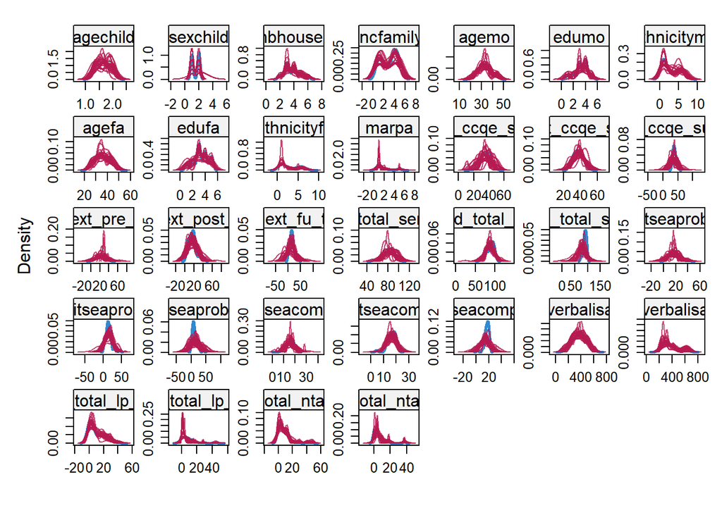

```r
# density plots
 densityplot(imp)
```

Imputed distributions look similar to the observed distributions. This is good.

# Imputation details

Multiple imputation by chained equations was performed using the mice package in R.

The imputation model included as predictors: groupand demographics variables of age and sex of child, age, education and ethnicity of mother and of father, family income, number of people in household, marital status of parents. Missing values for the following outcomes were imputed:

1. Sensitivity (NICHD-Sensitivity)
2. Positive parenting verbalizations (DPICS – LP)
3. Negative parenting verbalizations (DPICS – NTA)
4. Parental reflectiveness (CCQE)
5. BITSEA-competence
6. CBCL-externalizing
7. BITSEA-problem

Twenty-five datasets were imputed, using normal Bayesian linear regression for normal continuous variables, and predictive mean matching for count variables. No values were imputed for the waitlist group at follow up.

The unadjusted mixed model was run on each imputed dataset, and all results, including the group difference in change (primary outcome) and effect size were aggregated using Rubin’s Rules (1987).

References

Rubin, D.B. (1987) Multiple Imputation for Nonresponse in Surveys. John Wiley & Sons Inc., New York. http://dx.doi.org/10.1002/9780470316696

R Core Team (2024). R: A Language and Environment for Statistical Computing. R Foundation for Statistical Computing, Vienna, Austria. https://www.R-project.org/.

Stef van Buuren, Karin Groothuis-Oudshoorn (2011). mice: Multivariate Imputation by Chained Equations in R. Journal of Statistical Software, 45(3), 1-67. DOI 10.18637/jss.v045.i03.